# Notes on the FORUM-ASIA Human Rights Defenders dataset

Author

Sean Ng

Published

August 9, 2024

## Dataset

```
Rows: 4,914
Columns: 23
$ serial_number            <dbl> 1, 2, 3, 4, 5, 6, 7, 8, 9, 10, 11, 12, 13, 14…
$ title                    <chr> "Vietnam: blogger sentenced to 8-year jail te…
$ date_added               <chr> "14/05/2023", "14/05/2023", "15/05/2023", "15…
$ template                 <chr> "Event", "Event", "Event", "Event", "Event", …
$ country                  <chr> "Viet Nam", "China", "Sri Lanka", "Thailand",…
$ initial_date             <chr> "12/05/2023", "11/05/2023", "10/05/2023", "10…
$ final_date               <chr> NA, NA, NA, NA, NA, NA, NA, NA, NA, NA, NA, N…
$ event_description        <chr> "A court in Vietnam’s Ho Chi Minh City on Fri…
$ impact_of_event          <dbl> 1, 1, 1, 9, 2, 2, 1, 2, 1, 1, 1, 1, 1, 1, 3, …
$ gender_of_hrd            <chr> "Man", "Man", "Man", "Woman|Man", "Man", "Man…
$ violation                <chr> "(Arbitrary) Arrest and Detention|Enactment o…
$ rights_concerned         <chr> "Online|Right to liberty and security", "Offl…
$ hrd                      <chr> "Blogger/ Social Media Activist", "Lawyer|Pro…
$ perpetrator_state        <chr> "Judiciary", "Judiciary", "Government|Police"…
$ perpetrator_non_state    <chr> NA, NA, NA, NA, NA, "Non-state", NA, NA, NA, …
$ source                   <chr> "[RFA](https://www.rfa.org/english/news/vietn…
$ monitoring_status        <chr> "Pending", "Pending", "Pending", "Pending", "…
$ summary_for_publications <chr> "On 12 May 2023,Tran Bang, detained blogger, …
$ related_events           <chr> "Vietnam: ailing blogger arrested|Vietnam: bl…
$ geolocation              <chr> "10.778283733004596|106.68908174722719", "23.…
$ documents                <lgl> NA, NA, NA, NA, NA, NA, NA, NA, NA, NA, NA, N…
$ attachments              <chr> NA, NA, NA, NA, NA, NA, NA, NA, NA, NA, NA, N…
$ published                <chr> "Published", "Published", "Published", "Publi…
```

We concern ourselves first with the columns `violation`, `rights_concerned` and `hrd`, the most commonly used of the columns. However, we first need to pivot the data into a longer format and have combined these three columns into a new one called `event_tags`, with the category (violation, rights, hrd) being pushed to the new column `category`.

Below is a table of the top 15 event tags, by number of reports:

FORUM-ASIA reports by report tag, top 15 results

| event_tag | category | reports |
| --- | --- | --- |
| (Arbitrary) Arrest and Detention | violation | 2097 |
| Judicial Harassment | violation | 2077 |
| Right to liberty and security | rights | 1474 |
| Right to healthy and safe environment | rights | 1394 |
| Freedom of assembly | rights | 1281 |
| Intimidation and Threats | violation | 1145 |
| Pro-democracy defender | hrd | 1094 |
| Violence (physical) | violation | 1073 |
| Right to Protest | rights | 975 |
| WHRD | hrd | 922 |
| Media Worker | hrd | 835 |
| Community-based HRD | hrd | 556 |
| Student | hrd | 370 |
| Freedom of movement | rights | 359 |
| Administrative Harassment | violation | 351 |

`(Arbitrary) Arrest and Detention` and `Judicial Harassment` seem to be the preferred repression strategies in Asia.

### Questions about how the data was encoded

Whilst most reports have several types of tags, i.e. `Freedom of Movement` would likely co-occur with `Travel Restrictions` when reported. Or that a report about `Censorship` would also involve at least one `Media Worker`.

With that in mind, let us take a look at a sample of report summaries, that only have one tag category – either only rights, or violations or only HRDs were coded in for each of the following reports:

Sample of reports with only one type of tag

| serial_number | summary_for_publications | category | tags |
| --- | --- | --- | --- |
| 4381 | On the night of April 14, 2014, Mr. Sivagnanam Selvatheepan, a Tamil journalist, was attacked by two masked men with metal rods in the Puraapporukki area of Jaffna Peninsula, in Northern Sri Lanka. Se… | violation | Intimidation and Threats |
| 4635 | On September 22, human rights activist Xu Yishun (???), of Baoding City, Hebei Province, returned home after completing an 18-month Re-education through Labor (RTL) punishment at the Gaoyang RTL, and … | violation | (Arbitrary) Arrest and Detention |
| 4728 | Two journalists were displaced from Pathari in Morang district after frequent life threats over the issue of news coverage. Arjun Jamneli Rai, correspondent of Aujar Daily, and Bibek Bhattarai, corres… | rights | Right to liberty and security |
| 4807 | Mr Shadrake, a freelance writer and journalist, has written a compelling book looking behind the scenes of Singapore's execution machine. The death penalty, as it is applied in Singapore, hangs on ave… | violation | Censorship |
| 4812 | The Human Rights Commission (Suhakam) was barred from entering the construction site of the new palace last night, when it attempted to investigate reports about the deplorable living conditions of mi… | rights | Freedom of movement |

Let us expand our search to look at some samples of events with a low number of tags, outside of the ones mentioned above:

Sample of reports with low numbers of tags

| serial_number | summary_for_publications | event_tags | categories |
| --- | --- | --- | --- |
| 443 | On 1 October 2022, Jorginho dos Santos and Domingos Gomes, medoa workers, were summoned by the police for publishing two articles on a recent political development in Dili, Timor Leste. | Judicial Harassment, Media Worker | violation, hrd |
| 4740 | Ms. Sunita Devi is a Dalit widow and member of the organizational unit and the Self Help Group (SHG) unit of the Indian NGO PariOn 16 January 2011, Ms. Sunita Devi, a Dalit widow and member of the org… | Freedom of assembly, Violence (physical) | rights, violation |
| 4683 | The shooting of a Mumbai crime reporter in broad daylight has stunned India's financial capital and brought into sharp focus the seedy underside of the metropolis. Jyotirmoy Dey, 56, wrote extensively… | Right to information, Death | rights, violation |
| 1158 | On 3 November 2021, Meer Faisal, Shyam Meera Sing, and Sartaj Alam, media workers, were among those investigated on terrorism allegations for reporting communal violence against Muslim by the police f… | Judicial Harassment, Media Worker | violation, hrd |
| 4634 | Since September 23, authorities have detained Zhu Yongjian (???), a petitioner from Xukou Town, Wuzhong District, Suzhou City, Jiangsu Province, after taking him into custody in Beijing. Zhu was able … | Right to information, (Arbitrary) Arrest and Detention | rights, violation |

I am not familiar with FORUM-ASIA’s methodology; however, I do think that some reports would benefit from additional review, at least so that the type of human rights defender involved as well as the underlying causes are more thoroughly tagged.

As the other entries above show, this is more widespread in the dataset than initially thought and reports with low numbers of tags should be revisited.

## Network graph of event tags

Below is a network graph of event tags. These span the columns `rights_concerned`, `violations` and `hrd` in the original dataset.

The thickness of each line represents how many events were reported with both tags; the transparency indicates the strength of the correlation between each tag.

The dimensions of human rights, human rights violations and human rights defenders are not separate in the slightest. There is an argument to having these three columns in the original collapsed into an `event_tag` column.

From the graph below, we identify several “axes of repression” commonly applied by state and non-state actors. The first of which is the coincidence between **(Arbitrary) Arrests and Detention**, **Judicial Harassment** and the **Right to liberty and security**. This is commonsensical.

As are the relationships between **Restrictions on movement**, **Travel restrictions** and **Surveillance**, and between **Land rights**, **Minority rights** and **Indigenous people’s rights**.

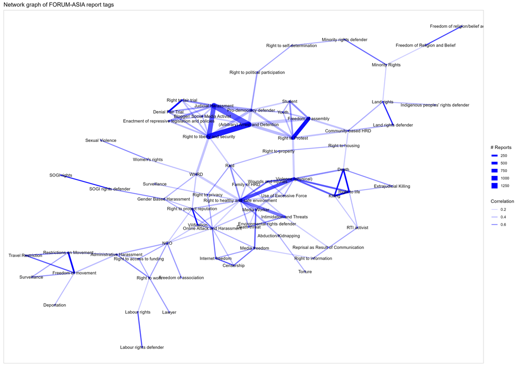

From the graph above, we also note that the **Right to healthy and safe environment** is probably too broad of a tag and needs to be broken up, containing many disparate themes and topics, perhaps separating out denial of basic services and other sub-categories. Below is a sample of summaries for publication of reports tagged with **Right to healthy and safe environment**:

Summaries of reports tagged with 'Right to safe and healthy environment'

| Summary for publications |
| --- |
| On 4 May 2019, rights activist Sultana Kamal filed a General Diary to Dhanmondi Police Station, over "threat by a militant group to kill" three eminent citizens. |
| On 13 May 2020, Rowena Carranza-Paraan, media worker, was victim of online red-tagging by an unkown social media account suspectedly linked to the Government in the Philippines. |
| On April 7, 2021 17 pro-democracy protesters were killed, unknown were injured and arrested by police and soldiers as they took on the street in Sagaing and Bago, Myanmar |
| On March 7, 2021 Aung Myat Lin, pro-democracy defenders was killed and 6 injured by the use of live and rubber bullets and stun grenade while protesting by police and soldiers in Magway, Myanmar |
| From 22 January 2022, Rana Ayyub, WHRD and media worker, received multiple online attacks including death and rape threats in social media after after criticising the ruling party and a foreign countr… |

### Perpetrators

Perpetrators in the FORUM-ASIA dataset and reports associated with them

| perpetrator | n |
| --- | --- |
| NA | 4318 |
| Police | 1973 |
| Government | 875 |
| Judiciary | 788 |
| Unknown | 477 |
| Non-state | 329 |
| Armed forces/ Military | 230 |
| Suspected state | 157 |
| Suspected non-state | 53 |
| Extremist group | 44 |
| Agricultural business | 32 |
| Corporation (others) | 29 |
| Extractive industries | 17 |

As with the other variables, let us take a sample of the data, this time from where where the perpetrator is blank:

Summaries of events where the `perpetrator` column is blank

| summary_for_publications |
| --- |
| On 12 April 2013, Li Wenjuan - who has spent time inside the Masanjia Women's Re-eduction Through Labor facility in Liaoning province, had 10 police officers bash down her door and tried to take her a… |
| On 18 March 2013, the Special Rapporteur on freedom of expression, the Special Rapporteur on freedom of assembly and association, the Special Rapporteur on HRDs, and the Special Rapporteur on Myanmar … |
| Mr. Ardiansyah Matra'is was killed in Indonesia. Mr. Ardiansyah Matra'is was a journalist who regularly reported on corruption aOn 28 July 2012, Mr. Ardiansyah Matra'is, journalist, had been reported … |
| On 21 November 2010, an unidentified phone caller issued threats to Chief Justice ABM Khairul Haque and his family members, just three days after two Molotov cocktails were hurled on the compound of h… |
| Chinese authorities have detained a number of activists across the country in recent days for online comments and activities linked to the 26th anniversary of the 4 June 1989 crackdown on the student-… |

Given the inclusion of the options `Unknown`, `Suspected state` and `Suspected non-state`, there should be no NAs in the perpetrator column. Additionally, in many of the samples checked, the perpetrator was clearly identifiable.

## Next steps

Not that I am proposing that I do these or be involved in these. These are just the next steps I would take:

*Review FORUM-ASIA’s methodology, codebook and other documentation. Mainly for all the points mentioned above, but also to see `Impact of event` has been calculated. As we consider this dataset for inclusion in the Crisis Risk Dashboard, collecting all available documentation will aid in that determination.

*Re-code the data to ensure that events are properly tagged and perpetrators correctly identified. More accurate coding allows for much more analysis, allowing for greater advocacy and the development of mitigative measures. One such analysis would be looking at which types of repressive measures are favoured by which type of actor, as well as to explore events where the perpetrator is truly unknown.

*Conduct analysis by country and perpetrator.

*Conduct text mining of the full text of reports. A network graph of words may help set a new base for refining how each report has been tagged.